# Empire Builder

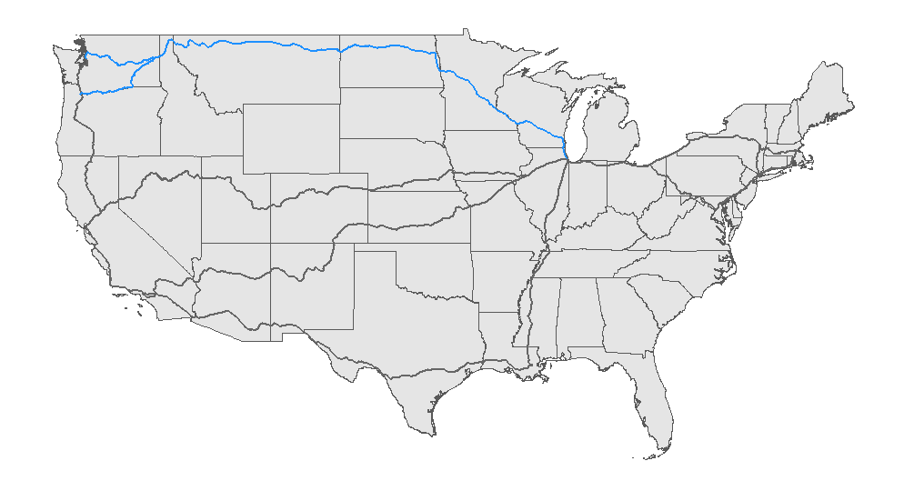

| **Name** | Empire Builder |
| --- | --- |
| **Start** | Chicago |
| **End** | Seattle |
| **Distance** | 2,206 miles |
| **Duration** | 46 hours |
| **Creation** | 1929 by the Great Northern Railway |

### August 14

All I have to say so far is this was very confusing! Unlike the Lake Shore Limited where Boston and New York met in Albany to form one long train to Chicago, the Empire Builder starts as one long train and eventually splits off with half going to Seattle and half going to Portland. There were so many lines and so many entrances to the train that I have no idea where I will end up! (I am at least taking comfort in the fact that other people on this train say they are going to Seattle, even though the conductor initially thought I was going to North Dakota….) I have a seat, I am by the window, and everything else will work itself out!

I’m not sure that I will see much today. Based on this map of estimated day/night location, it will likely be dark before we reach Minnesota.

Update: I was just kidding!!! Look, it’s a sunset over the Mississippi River between Wisconsin and Minnesota! (And then look at the day/night map because it is also really cool)

[video not shown]

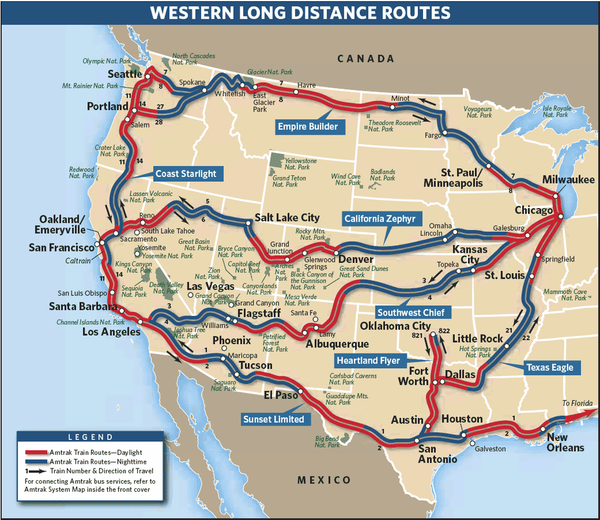

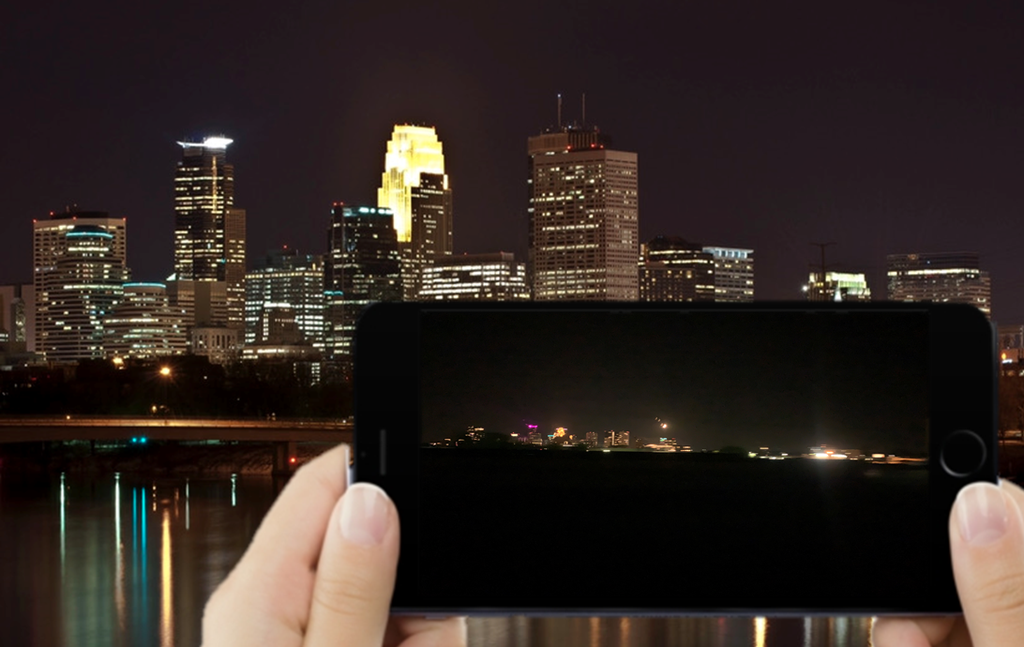

### August 15

After my new showering routine, I grabbed my breakfast and espresso and headed to the observation car.

[video not shown]

I have to be honest and say that North Dakota blended into Montana so I am not sure if this is the actual split. I remember thinking: “wow, there are a lot of hills/mountains here, I wonder where we are?” and seeing on Google we were well into Montana.

[video not shown]

Either way, I spent the day in the observation car *observing* and also reading my book on Amtrak. (I’ll start a new tab on the main page for some interesting things about that.) So far I have not purchased anything from the Cafe car and have subsisted off of the groceries I brought on board! As I wait to start dinner, we are racing the daylight towards Glacier National Park (Amtrak is not taking it as seriously as I am, unfortunately). The day/night map says we should have daylight right until we get to the park. The path through looks incredible, so I am hoping it is not completely pitch black. I also think we are splitting soon, so the moment of truth as to which destination I am headed towards is approaching…

[video not shown]

After passing through the mountains, we ended up in Whitefish. I was hoping to get a glimpse of the lake by the town, but we were stopped at the station for awhile and it quickly became dark. I’m honestly just so happy to have seen the mountains that anything else at this point is just a bonus. Also, I caved and bought a beer (at a New York price). But, it was absolutely worth it because I got to sit without a mask on for a bit!

Tonight we will pass through the sliver at the top of Idaho into Washington. I will likely be alseep by then, or it will be too dark to see anything, but my unconscious body will have been to Idaho! Apparently we do not split cars until Spokane, so I won’t find out my fate until I wake up and see which direction I’m headed in! (To my mom and everyone else worried about this joke, mostly, I am surrounded by people going to Seattle and I think there is only one Portland coach car. I just think it should be MUCH clearer where the cars are going to be SPLITTING apart.)